# IBM Capstone Project: Battle of the Neighborhoods, A Short Blog Post

This report will explain the Chicago Neighborhood Opportunity Fund allocation.

## Introduction

### The Study

While researching a topic for this capstone project, I came across an academic paper that influenced where millions of dollars of development funds will be used. The "Neighborhood Opportunity Fund" [(NOF)](https://neighborhoodopportunityfund.com) in Chicago can award up to \$2.5 million for individual projects in "Qualified Investment Areas." Information on the program explained that the choice of geographic areas to receive the grants was influenced by the study ["Mapping the DNA of Urban Neighborhoods: Clustering Longitudinal Sequences of Neighborhood Socioeconomic Change"](https://www.tandfonline.com/doi/full/10.1080/00045608.2015.1096188) by Elizabeth Delmelle. The study classified neighborhoods by socioeconomic, housing, and demographic variables using US census data from the years of 1970 to 2010, so that it could be used to identify areas in need of investment. Throughout this report I will refer to the study as "Dr. Delmelle's study," the "DNA of Urban Neighborhoods study," or the "2010 study." 2010 is the year of the latest data used in the study, not its publication date.

This project will try to repeat and extend this study with the latest census data (2019), then compare the new results to the locations of where some of the funds are going to be awarded. The objective will be to evaluate if the funds, given the updated information, are going to neighborhoods most in need of investment. The original study examined both Chicago and Los Angeles. This project will only address Chicago.

#### Replication

Years back I read the paper [Why Most Published Research Findings Are False, by John P. A. Ioannidis,](https://journals.plos.org/plosmedicine/article?id=10.1371/journal.pmed.0020124) also described in [Wikipedia](https://en.wikipedia.org/wiki/Why_Most_Published_Research_Findings_Are_False). It raised the concerns that, even though replication is an essential part of science, few replications are attempted and even fewer are done successfully. Dr. Delmelle's study was very interesting, utilized much of the algorithms taught in the IBM online courses, and will influence the allocation of millions of dollars in taxpayer money. It's worth replicating it, to the extent possible, and updating it with the latest data available.

This project won't reproduce the exact results of the previous study for a number of reasons:

1. The original study starts off using K-means clustering, which is a technique sensitive to which initial values are chosen, therefore since initial values often are chosen at random, exact replication cannot be guaranteed.
2. I will update the census data with 2019 data from the American Community Survey. So I'll be using a larger dataset.
3. The previous study did not publish the exact data cleaning process or the classification of every single census tract, so a higher-level comparison will have to do.

#### Where the Money Is Going

An organization called [INVEST South/West](https://www.chicago.gov/city/en/sites/invest_sw/home.html) is in charge of allocating much of the NOF for parts of Chicago. They have an [RFP page](https://www.chicago.gov/city/en/sites/invest_sw/home/requests-for-proposals.html) explaining how developers can solicit these funds for projects in predetermined locations. I manually transcribed the addresses of the RFPs into a CSV file and will be adding to that dataset using Python libraries throughout this study.

## Data

### Alternative Geospatial Data to Foursquare

I'd like to note since the instructions say use Foursquare data, I received explicit permission from the teaching staff to use alternate data. The message is in the discussion forum [here](https://www.coursera.org/learn/applied-data-science-capstone/discussions/weeks/4/threads/2jXGqc01Eeu9FxIkXkJf1Q).

The message from Lakshmi Holla states:  
"*As you are using geospatial data which is also location based you can use it instead of foursquare.*

*Hope this helps.*"

### Data Sources

[Longitudinal Tract Data Base (LTDB)](https://s4.ad.brown.edu/Projects/Diversity/researcher/ltbddload/datalist.aspx). This is the data used for the original study. It contains census data from 1970 to 2010. It is downloadable as zip files from an interactive menu from the web link given. The file names to download are LTDB_Std_All_fullcount.zip and LTDB_Std_All_Sample.zip.

[American Community Survey Data (ACS)](https://www.census.gov/programs-surveys/acs/data.html). This will be from the five-year survey for 2019. It will be retrieved using the U.S. Census API via the Python library "censusdata."

[Census shape files](https://www2.census.gov/geo/pvs/tiger2010st/17_Illinois/17031/tl_2010_17031_tract10.zip) for tract geospatial information. These are zip files downloaded with a "curl" command. I use the Python library "GeoPanda" to convert the shape files in NAD83 coordinates to GeoJSON in WS84 coordinates. I found GeoJSON easier to work with during debugging, plus the Python library "Folium" defaults to WS84.

The original "Mapping the DNA of Urban Neighborhoods" study. Some tables are extracted from the PDF using the Python library "tabula."

[RFP's](https://www.chicago.gov/city/en/sites/invest_sw/home/requests-for-proposals.html) to receive Neighborhood Opportunity Funds. Each RFP is eligible to receive from \$250,000 to $2.5 million in funding. I had to manually transcribe the addresses from the RFP into a CSV and then use the Python library geopy to update the geospatial data to use it as input to the library Folium.

## Following Dr. Delmelle's Process

The original study sketched out the following process that we will replicate:

[figure not shown]

We start out doing K-means clustering and later use hierarchical agglomerative clustering. Each of those steps deserved their own section so we will have more than one data and methodology section, since the narrative will make more sense if we keep the descriptions of the data cleaning close to how they are used.

In summary:

- The K-means clustering classifications of the census tracts are lined up as a series, each year being one data item in the series. That series is input for the next step.
- Difference for each tract series is calculated by the optimal matching distance algorithm (OMA). This creates a difference matrix which is input for the next step.
- Based on the series difference, the census tracts are classified by hierarchical agglomerative clustering. This is our final classification.

## K-means Clustering by Census Data

The data for the original study was obtained from the "Diversity and Disparities" project hosted at Brown University and can be downloaded from the [link](https://s4.ad.brown.edu/Projects/Diversity/researcher/ltbddload/datalist.aspx) already given. The "DNA of Urban Neighborhoods" study gave a description of the variables used. From those descriptions I determined that they correspond to the variables shown below in the LTDB and ACS tables. All of the variables are percentages except for median home value. By combining all this data I was able to recreate variables in the original report, as listed below

1. % four-year degree
2. % unemployment
3. % working in manufacturing industries
4. % below poverty
5. % houses more than 30 years old
6. % households that moved less than 10 years ago
7. % over 59
8. % under 19
9. % vacant units
10. % owner-occupied units
11. % units in multi-unit buildings
12. median home value

All data are defined on the census tract level. Census tracts are defined as small, relatively permanent statistical subdivisions of a county as part of the Census Bureau's Participant Statistical Areas Program. Census tracts generally have a population size between 1,200 and 8,000 people, with an optimum size of 4,000 people. A census tract usually covers a contiguous area.

#### Data: K-means: Data Cleaning

While processing the data I did notice some missing values and outliers. A few calculated values had the Python number for infinity, indicating there is data with zero in the total that I used as the denominator calculating a variable. In the end I discovered the number of bad data points, listed in the table below:

|  | 1970 | 1980 | 1990 | 2000 | 2010 | 2019 |
| --- | --- | --- | --- | --- | --- | --- |
| NaN | 41 | 309 | 1 | 2 | 0 | 0 |
| Outlier | 105 | 57 | 85 | 66 | 62 | 71 |
| Percent bad | 0.92% | 2.32% | 0.54% | 0.43% | 0.39% | 0.45% |

We can visualize the outliers for 1970, (the year with the most outliers) with a box plot:

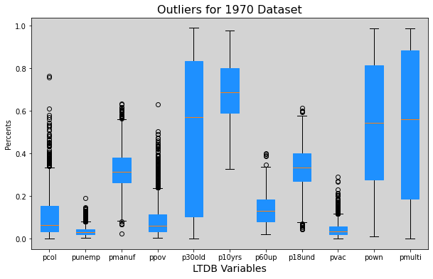

Bad data was replaced by the median values.

As indicated in Dr. Delmelle's study I will transform the data to their Z-values for each variable for each year, to control for different measurement scales and to compare changes across time. In other words, since we are ranking census tracts against each other, we only care about relative values.

Since the number clusters were determined by the study I am replicating, I don't have to analyze runs with the "elbow method" to determine the best number of clusters. K-means is known to be sensitive to initial conditions so I ran the fit 9 times with random_state set to a different number each time, then saved the one with the lowest sum of squared distances to closest cluster center, as saved in the "inertia_" attribute. All these metrics were very close, so I don't think this step was critical to better performance.

My objective here is to pair up the clusters created with the updated data with the clusters of the previous study. Those clusters classified neighborhoods as:

1. New Suburban
2. Older, Stable Suburban
3. Blue Collar
4. Struggling
5. Young Urban

The original study did not list a per-census-tract classification by K-means, but in the appendix there was a table that has the mean Z scores for each variable for each cluster.

I was able to line up the new clusters with the old labels with the following process:

1. Find maximum for manufacturing employment, assign that to Blue Collar
2. Find maximum for poverty of remaining clusters, assign that to Struggling
3. Find minimum for structures over 30 years of remaining clusters, assign that to New Suburban
4. Find minimum for people living at their residence less than 10 years of remaining clusters, assign that to Old Suburban
5. Assign last cluster to Young Urban

To get an intuitive look at how the variables line up from the 2010 study to my update with 2019 data, here I plot a comparison bar chart of some of the most informative variables' mean Z-score.

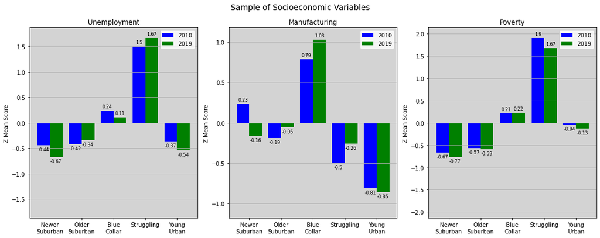

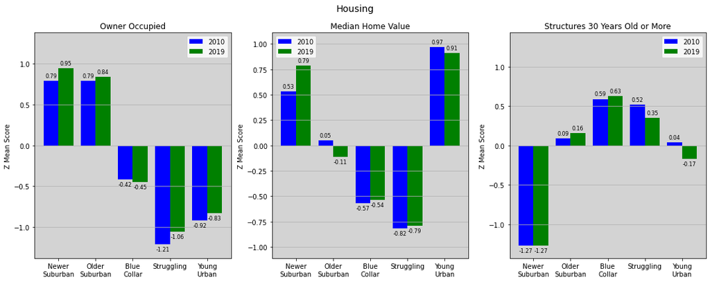

The original study did not map this intermediate data, but this project will for a quick visual sanity check.

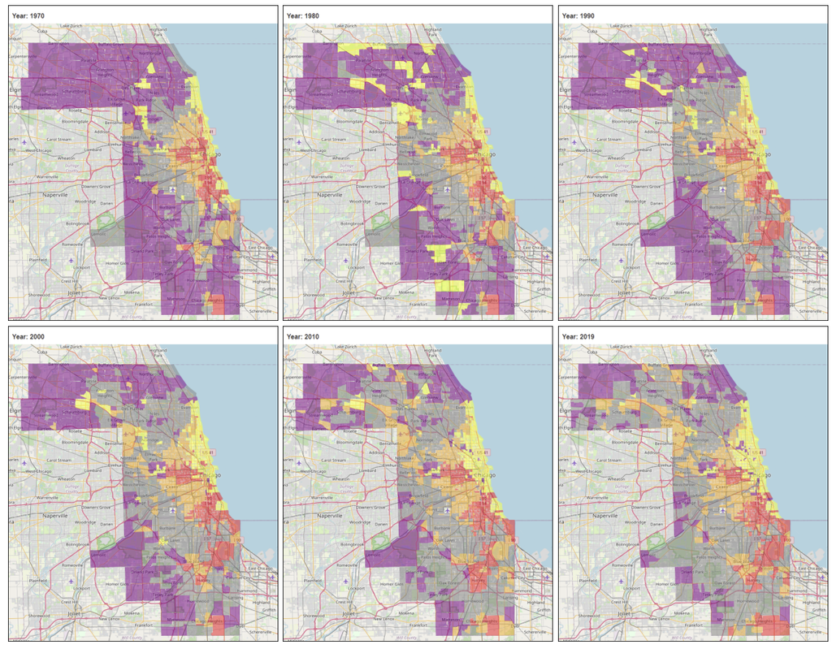

▮ New Suburban ▮ Old Suburban ▮ Blue Collar ▮ Struggling ▮ Young Urban

A visual inspection of the maps would seem reasonable to anybody familiar with the Chicago area. The red areas are the traditionally poorer areas of Chicago, the orange are traditionally modest middle class. The Young Urban yellow areas are expanding over time into places that have been known to be gentrified. Intuitively, over time the New Suburban areas become Old Suburban areas, since all you have to do for that is wait and age.

## Optimal Matching Distance Algorithm (OMA)

By using the "DNA of Urban Neighborhoods" study, the NOF grants are considering not only the present state of a neighborhood but also its trajectory over time. This trend information is relevant because a struggling but gentrifying area may not need the funds as much as a blue collar neighborhood that is starting to struggle, and certainly areas stuck in a stable long-time stagnation would need the most attention.

### Data: Optimal Matching Distance Algorithm (OMA):

The input for the OMA must be a series, therefore each data row is one census tract with each classification for each year as a categorical variable from 1970 to 2019. The output is a dissimilarity matrix.

## Hierarchical Agglomerative Clustering

### Data: Hierarchical Agglomerative Clustering

The final stage in my categorization of Chicago neighborhoods uses the output of the OMA algorithm, which is a distance matrix of all the census blocks sequences. The difference matrix created by TraMineR library in R is saved to disk as an R data type file (typically called an RDS file for the default extension). The data is read back into Python using the pyreadr library, which allows the user to directly import R data structures into Python.

### Methodology: Hierarchical Agglomerative Clustering

The same options for hierarchical clustering weren't availble in R and Python. The original report was done in R. I ran the clustering in R and then all options in Python to compare the Python results with the results in R and the results in the 2010 study. To determine what the right cluster solution might be took quite a bit of data analysis, not all of which needs to be repeated in this post.Here, I will go over on a high level, the steps to determine what were the correct coding options to get credible results.

[figure not shown]

To start off I did not have to choose the number of clusters. In order to replicate and update the 2010 report, I used 10 clusters as did the original report. Here we have a nice graphic from the original report summarizing the clusters as of 2010 data. They are:

1. Upgrading from Struggling
2. Blue Collar to Young Urban
3. Stable Young Urban
4. Stable Older Suburban
5. Stable Older Suburban to Blue Collar
6. Persistently Struggling
7. Stable Blue Collar
8. Blue Collar to Struggling
9. Newer Suburban to Stable Older Suburban
10. Newer Suburban

Because I am updating the report with 2019 census data, results will be only close to the 2010 study, but not exact. The R clustering will use the same options as the original report (i.e. distance matrix with Ward's method). It will serve as a point of comparison for Python produced clusters. In other words it will serve as a rough baseline for my Python models.

### Classifying the New Clusters

First, I need to align my new clusters' categories with categories defined in the 2010 report. Using Matplotlib's pcolormesh graphic in Python I was able to create a graphic that shows the dominant sequences in the clusters created using AgglomerativeClustering in Python. It did rather well.

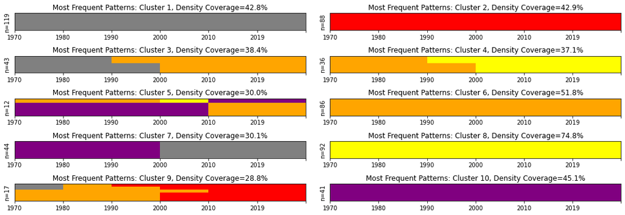

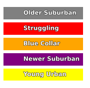

I had my R baseline and two Python models acceptably lined up with the cluster labels from the original report: Ward's method and the minimizing maximum distance metrics. My R and Python clusters lined up, matching the sequence patterns of the 2010 clusters 9 out of 10 times, with each new model missing one of the original patterns, but each new model missing a different pattern from the others. Using the R model as the baseline I decided to compare the Python models to it using [Jaccard similarity.](https://en.wikipedia.org/wiki/Jaccard_index) The Jaccard index is used to compare two sets. It divides the number of data points in common in the two sets (the intersection) by the number of all the unique data points of both sets (the union), thus 1 is everything in common and 0 is nothing in common. I did this for each aligning the overall data sets.

To compare the overall Jaccard similarity, I created lists for each model with each census tract number concatenated with its assigned cluster. The results for the similarity are:

```
			The similarity of Ward's Method model to the R baseline has a Jaccard score of 0.53
			The similarity of the maximum distance model to R baseline has a Jaccard score of 0.634
```

So overall the model using maximum distance seems to be the most appropriate.

## Where the INVEST South/West Funds Will Go

Now I'm ready to return to the original question. INVEST South/West is about to award millions of dollars in grants to certain RFP locations, in part due to Dr. Delmelle's study that used data from 1970 ending in 2010. Given that I have updated this process with the latest census data available from 2019, can the original conclusions be confirmed? First, it's necessary to take a look at how each of the models has classified the census tracts that contain the points of interest.

Here are the census tracts that have RFP locations and how each of our models has classified them:

| Census Tract with RFP | R Clustering | Python with Ward | Python by Max Distance |
| --- | --- | --- | --- |
| 17031230500 | Stable Blue Collar | Stable Blue Collar | Stable Blue Collar |
| 17031231500 | Stable Struggling | Stable Struggling | Stable Struggling |
| 17031251200 | Stable Blue Collar | Stable Blue Collar | Stable Blue Collar |
| 17031292200 | Stable Struggling | Stable Struggling | Stable Struggling |
| 17031381200 | Stable Struggling | Stable Struggling | Stable Struggling |
| 17031381800 | Stable Struggling | Stable Struggling | Stable Struggling |
| 17031431301 | Stable Struggling | Stable Struggling | Stable Struggling |
| 17031460100 | Stable Struggling | Stable Struggling | Stable Struggling |
| 17031460700 | Stable Struggling | Stable Struggling | Stable Struggling |
| 17031611200 | Alternate Blue Collar, Young Urban | Blue Collar to Struggling | Stable Blue Collar |
| 17031710800 | Stable Blue Collar | Blue Collar to Struggling | Stable Blue Collar |
| 17031834800 | Stable Struggling | Stable Struggling | Stable Struggling |
| 17031843000 | Stable Struggling | Stable Struggling | Stable Struggling |

Most of the census blocks are classified as economically Struggling, but some are Stable Blue Collar. Let's zoom in using some visualization and see if this can provide any more clarity. Note that the RFP locations can have three statuses: **Awarded, Reviewing and Soliciting**. RFPs that have been awarded are in **green**, those that are being reviewed are in **yellow**, and those that are still being solicited are **red**.

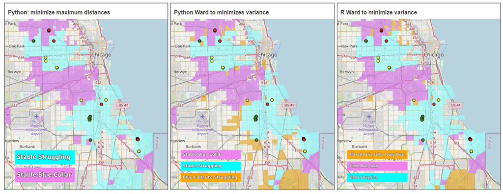

## Conclusion

With the help of maps it can be seen that most of the NOF RFP sites are in persistently economically disadvantaged neighborhoods, while those that are not technically classified as such by my models, are either on the border of an economically disadvantaged tract or in the case of the northernmost sites, very close to disadvantaged neighborhoods. So even in the latter case the update confirms the original conclusions that the neediest parts of the city would benefit directly or indirectly by some very close spillover from the economic incentives being offered by the Neighborhood Opportunity Funds, even when updated with 2019 data.